# Tidy Tuesday Week 11

Paige Richards

3/17/2020

## Mid Salaries versus percent in STEM

This week for my tidy tuesday, I wanted to try to ask a question with the dataset that I chose. I chose to look at the dataset with regards to salary potential. I decided to ask if in New Jersey there is any correlation between the percent of STEM students and the mid salary. From here, I wanted to learn a new skill which in this case was encircling some parts of the data! I also played around with the highlight of the YAML font of the Rmarkdown.

```r
read_csv('https://raw.githubusercontent.com/rfordatascience/tidytuesday/master/data/2020/2020-03-10/salary_potential.csv') -> salary
salary
```

```
## # A tibble: 935 x 7
##     rank name  state_name early_career_pay mid_career_pay make_world_bett…
##    <dbl> <chr> <chr>                 <dbl>          <dbl>            <dbl>
##  1     1 Aubu… Alabama               54400         104500               51
##  2     2 Univ… Alabama               57500         103900               59
##  3     3 The … Alabama               52300          97400               50
##  4     4 Tusk… Alabama               54500          93500               61
##  5     5 Samf… Alabama               48400          90500               52
##  6     6 Spri… Alabama               46600          89100               53
##  7     7 Birm… Alabama               49100          88300               48
##  8     8 Univ… Alabama               48600          87200               57
##  9     9 Univ… Alabama               47700          86400               56
## 10    10 Alab… Alabama               48700          83500               58
## # … with 925 more rows, and 1 more variable: stem_percent <dbl>
```

```r
salary%>%
  dplyr::filter(state_name == "New-Jersey") -> new_jersey_salary
new_jersey_salary #looking at ONLY new jersey schools
```

```
## # A tibble: 25 x 7
##     rank name  state_name early_career_pay mid_career_pay make_world_bett…
##    <dbl> <chr> <chr>                 <dbl>          <dbl>            <dbl>
##  1     1 Stev… New-Jersey            75100         139900               47
##  2     2 Prin… New-Jersey            75200         139400               48
##  3     3 New … New-Jersey            64600         121300               51
##  4     4 Rutg… New-Jersey            59800         111000               42
##  5     5 Seto… New-Jersey            57100         103800               45
##  6     6 Rutg… New-Jersey            57900         101800               52
##  7     6 The … New-Jersey            58200         101800               44
##  8     8 Ride… New-Jersey            51600          99000               47
##  9     9 Fair… New-Jersey            53700          98500               42
## 10     9 Fair… New-Jersey            53700          98500               42
## # … with 15 more rows, and 1 more variable: stem_percent <dbl>
```

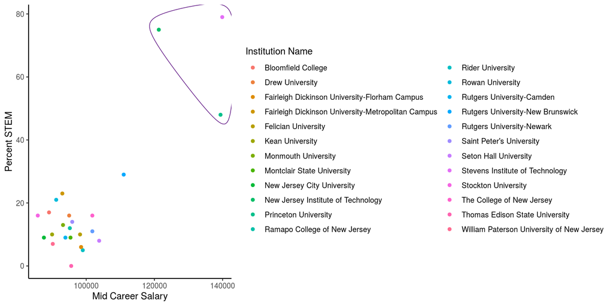

```r
ggplot(new_jersey_salary, aes(x=mid_career_pay, y= stem_percent))+
  geom_point(aes(color=name))+
  geom_encircle(data = subset(new_jersey_salary, stem_percent>= 45), color = "darkorchid4")+ #to do encircle, you need to specify the data subset! I chose greater than 45 percent. You need to specify the specific data frame that the variable
  labs(y = "Percent STEM",
       x= "Mid Career Salary",
       color = "Institution Name") -> salary_plot
ggsave('salary_plot.png', salary_plot,width = 10, height=5)
salary_plot
```

I learned a lot from this week’s Tidy Tuesday. I tried to ask a question of the data and interpret some things from it. I also wanted to learn how to encircle some of the datapoints. From research, I found a package known as ggalt which had a function known as encircle. From here, I wanted to only circle the data that had points greater than 45% (as a test). I was able to create a circle and customize the color of it to make it purple! It was exciting to ask a question and try to interpret some results from the data. If I were to make an inference from what I put here, I would say that it seems that the higher the percent, the higher the mid salaries are! I am not sure if I can make that conclusion with only three data points, but it was exciting to be able to try this out!